# Analyse de stabilité

### Enjeux

Dans le but d'établir **un contrat de maintenance** de l'algorithme de segmentation client, nous devons tester sa stabilité dans le temps et voir, par exemple, **à quel moment les clients changent de cluster**.

Pour cela, nous devons recalculer toutes les features en fonction d'une période donnée.

En d'autres termes, il s'agit de faire une simulation pour **déterminer la fréquence nécessaire de mise à jour du modèle de segmentation**. Pour cela, nous allons comparer les segments déjà fournis par notre algorithme avec ceux *du futur*. C'est l'indice de Rand qui nous permettra d'évaluer leur similarité.

### Indice de Rand

L'indice de Rand est utilisé pour **mesurer la similarité des points de données présents dans les clusters**. Plus précisément, il s'agit de prendre en compte toutes les paires d'observations et compter les paires qui sont assignées aux mêmes clusters (ou à des clusters différents).

Ainsi, **cette mesure doit être aussi élevée que possible**, sinon nous pouvons supposer que les points de données sont attribués au hasard.

### Méthodologie

Nous souhaitons donc savoir si notre algorithme fournira les mêmes segmentations dans le futur. Afin de simuler le futur, nous allons :

1. Mettre en place plusieurs jeux de données :
   - Dataframe de référence :
     - B0 à la date T0
   - Dataframes artificiels du futur :
     - B1 - B0 plus 1 mois (T1.merge(T0))
     - B2 - B0 plus 2 mois (T2.merge(T0))
     - B3 - B0 plus 3 mois (T3.merge(T0)) etc.
1. Ensuite nous allons effectuer un clustering sur les bases artificielles :
   - *C1_cluster.fit(B1_df)*
   - *C1_cluster.fit(B2_df)*
   - *C1_cluster.fit(B3_df)* etc.
1. Ensuite, nous allons générer une liste regroupant les labels (prédictions) attribués :
   - *cluster_labels_B1*
   - *cluster_labels_B2*
   - *cluster_labels_B3 etc.*
1. Finalement, nous allons comparer la segmentation entre C0 et Cx grâce à l'indice de Rand ajusté :
   - *adjusted_rand_score(cluster_labels_t0, cluster_labels_B1)*
   - *adjusted_rand_score(cluster_labels_t0, cluster_labels_B2)*
   - *adjusted_rand_score(cluster_labels_t0, cluster_labels_B3)* etc.
1. Affichage de l'évolution de l'indice de Rand ajusté.

**Se repérer sur l'axe du temps**

```python
from my_functions import *
import joblib
%reload_ext autoreload
pd.options.display.float_format = '{:.3f}'.format
```

```python
# Chargement du jeu de données
data = joblib.load('df_suite_eda')
```

```python
data.shape
```

```
(112782, 24)
```

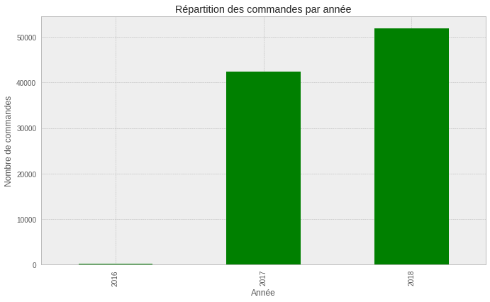

```python
# Affichage de la répartition des commandes dans le temps
data.groupby(data['order_purchase_timestamp'].dt.year)\
    .agg({"order_id": "nunique"})\
    .plot(figsize=(10, 6), kind="bar", color=['green'],
          title="Répartition des commandes par année",
          ylabel="Nombre de commandes",
          xlabel="Année",
          legend=False)
plt.show()
```

```python
print('Les commandes ont été passées du {} au {}.'.format(data['order_purchase_timestamp'].min(),
                                    data['order_purchase_timestamp'].max()))
```

```
Les commandes ont été passées du 2016-10-03 09:44:50 au 2018-08-29 15:00:37.
```

Le dataframe de référence sera construit sur l'année 2017 (12 mois). Pour les tests, nous allons utiliser les mois suivants de l'année 2018.